# Two Algorithms for Taxonomy Disjointness Maintenance

J S Jenkins

2019-06-06

# Introduction

One of the key features of the Semantic Web (and its formal foundations in Description Logic) is the so-called *open-world semantics*, which means simply that any unasserted fact may be true or false. The real world is open in just this way, although we rarely think about. If I do not assert that I am a graduate of UCLA, then (at least logically) I might or might not be.

Open-world semantics typically do not apply in traditional database applications. If my name does not appear in the table of customers, then an application is justified in concluding I am not (yet) a customer.

Neither open- nor closed-world semantics are “correct”, per se. Each has its appropriate uses, and it is important to be aware of the semantics in effect and draw proper conclusions.

One aspect of open-world semantics that is sometimes surprising to people familiar with object-oriented software development has to do with implicit *disjointness*. If, for example, in Java, we declare classes as follows:

```
// Java
public class Vehicle {}
public class Person {}
```

we naturally expect that an object may be a `Vehicle` or it may be a `Person`, but it cannot be both. That is, the sets of objects of type `Vehicle` and `Person` are *disjoint*. Formally, two sets are disjoint if their intersection is empty.

If instead, however, we want to declare classes that are not disjoint because one is a subclass of the other, Java requires us to declare the relation explicitly:

```
// Java
public class Vehicle {}
public class Car extends Vehicle {}
```

The situation with OWL and the Semantic Web is somewhat different. If we declare OWL classes

```
# OWL
Declaration(Class(Vehicle))
Declaration(Class(Person))
Declaration(Class(Car))
```

and assert nothing further, then any pair of classes may have a nonempty intersection. To assert the the situation from the Java example, we must add two axioms:

```
# OWL
DisjointClasses(Vehicle Person)
SubClassOf(Car Vehicle)
```

Note that we do not need to assert `DisjointClasses(Car Person)`; that fact follows from the definition of disjointness; a DL reasoner will infer it. Note also that, while it is probably not what we mean, it would not be logically inconsistent to assert `DisjointClasses(Car Vehicle)`; the reasoner would include that the set of cars is *empty*, but the empty set is a perfectly valid set. A class that can have no members is said to be *unsatisfiable*.

# Disjointness Maintenance

The general problem of disjointness maintenance is the augmentation of a taxonomy with disjointness axioms that encode a specific policy for vocabulary closure. It is of utmost importance to note that these disjointness axioms are in no sense *implied* by the taxonomy itself; indeed, the open world interpretation is that two classes are not considered to be disjoint unless explicitly declared to be so or if their disjointness is implied by mutually exclusive constraints such as property range or cardinality restrictions.

The policy to be implemented here is simple: any two classes that have no common subclass are considered to be disjoint. A simple corollary is that, if *B* is a subclass of *A*, then *A* and *B* are not disjoint because *A* and *B* have a common subclass, namely *B*. Also note that disjointness is inherited: if *A* and *B* are disjoint, then every subclass of *A* is disjoint with every subclass of *B*. We can use this fact to make our generated disjointness axioms concise.

This policy is inappropriate for, say, biological taxonomies in which we are trying to classify objects as they exist in the real world. In that case, disjointness is a feature to be discovered (or not). Developing a vocabulary for engineering, in contrast, involves identifying key concepts and noting that, in many cases, these concepts *are* disjoint. By definition, an engineering requirement, the component bound by that requirement, and the supplier of that component, *cannot* be the same thing; they belong to disjoint categories. It is perfectly appropriate in this cases to declare our intent that the classes *Requirement*, *Component*, and *Supplier* and disjoint.

The implemented policy simply makes disjointness the default. Exceptions must be stated explicitly.

The objectives of a disjointness maintenance algorithm are threefold:

1. to implement the disjointness policy,
2. to minimize the number of disjointness axioms generated, and
3. to generate disjointness axioms of tractable computational complexity for a reasoner.

The last item is beyond the expertise of the author. We focus on the first two and hope for the best with the third.

## The Simplest Case

Consider the case of a taxonomy that is a *directed rooted tree* in the graph-theoretic sense. A *tree* is an undirected graph that is connected and acyclic. (An equivalent formulation is that there is exactly one path between any two vertices.) A *directed tree* is a tree in which the edges are directed, and a *rooted tree* is a directed tree in which a single vertex is designated the *root*. For this discussion we will take edge direction to be from subclass to superclass; the root vertex corresponds to `owl:Thing`.

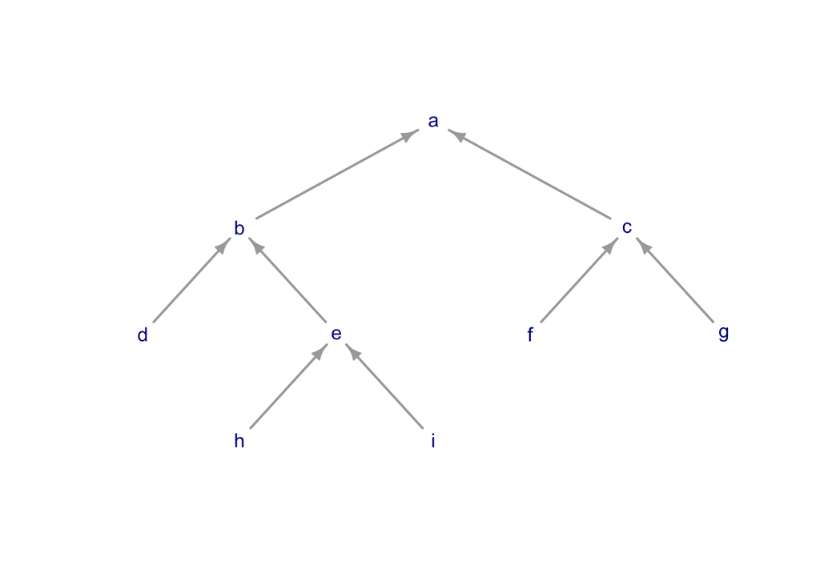

It is easy to show that declaring all sibling subclasses of any common superclass disjoint satisfies the disjointness policy. We prove it in two steps:

1. *Necessity*: Any two sibling subclasses *A* and *B* of a common superclass cannot share a common subclass. If a common subclass existed, there would be two paths to the root from it: one through *A* and one through *B*. Every tree contains exactly one path between any pair of vertices, so a common subclass cannot exist.
2. *Sufficiency*: If two classes *A* and *B* do not share a common subclass, then neither one is a subclass of the other. Consequently, the path from *A* to the root contains at least one edge not in the path from *B* to the root and vice versa. Therefore, there must exist some vertex *C* (perhaps the root) where the paths from *A* to the root and from *B* to the root converge. That is, there must exists sibling subclasses *C<sub>A</sub>* and *C<sub>B</sub>* such that *A* is a subclass of *C<sub>A</sub>* and *B* is a subclass of *C<sub>B</sub>*.

The disjointness algorithm for a tree is therefore simple:

1. Traverse the tree
2. Declare the sibling subclasses of each parent class disjoint

For our example problem, the result is

```
DisjointClasses( b c )
DisjointClasses( d e )
DisjointClasses( f g )
DisjointClasses( h i )
```

## The General Case

In the general case, we cannot assume the taxonomy is a tree. There may be explicitly-asserted common subclasses, and these invalidate the assumptions that led to the simple algorithm in the simple case.

One possible strategy for dealing with the general case is to apply a set of transformations to an arbitrary taxonomy that result in a tree and then apply the simple algorithm to the tree. These transformations should be chosen in such a way that the disjointness policy is still satisfied: that every pair of classes without an explicit common subclass is disjoint. In the event we cannot find a transformation that preserves the policy, it is important to ensure that the transformed taxonomy does not result in spurious unsatisfiability. That is, the transformed (relaxed) taxonomy may generate weaker disjointness constraints than the original, but must not generate stronger constraints than implied by the original.

### Transitive Reduction

The subclass relation is *transitive*, that is, if *a* is a subclass of *b* and *b* is a subclass of *c*, then *a* is a subclass of *c*. It is true in this case that *a* is a common subclass of *b* and *c*, but so is *b*. The fact that *a* is a subclass of *c* does not rule out any disjointness not already ruled out. In the following discussions of algorithms, we will assume that the input has undergone [*transitive reduction*](https://en.wikipedia.org/wiki/Transitive_reduction) and is maintained in reduced state.

# Two Algorithms

This section will describe two algorithms for transforming an arbitrary rooted taxonomy into a tree such that every subclass relationship in the resulting tree is implied by the initial taxonomy (but not necessarily vice versa). The algorithms are designated *merge* and *bypass-reduce-isolate*.

## Example Cases

Before describing the algorithms, we introduce some example taxonomies as use cases.

### Simple Diamond

This case is the simplest occurrence of a rooted tree with a class that subclasses two other classes.

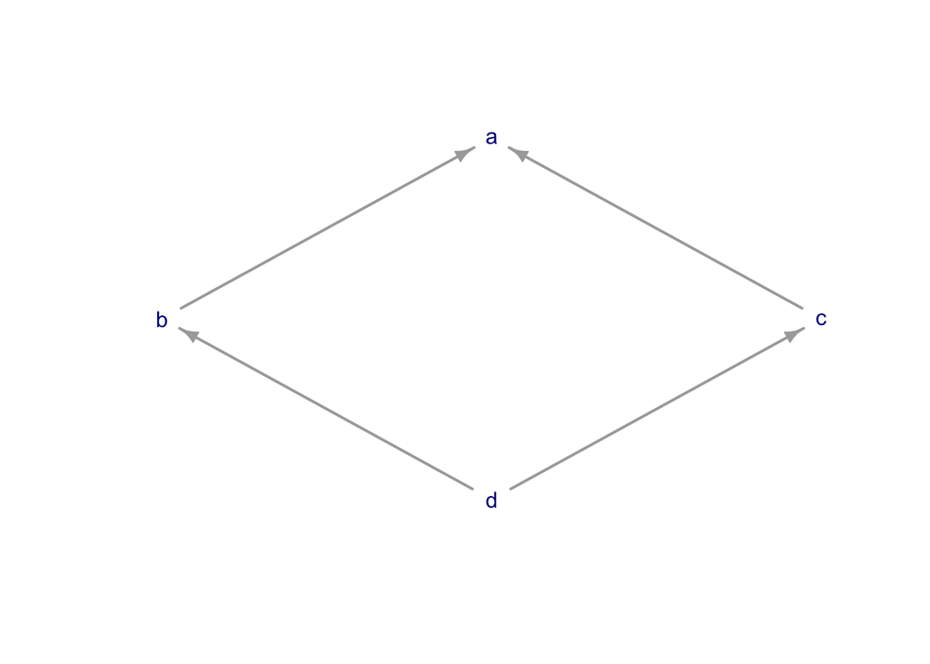

### Symmetric 8

This case is a deeper symmetric tree.

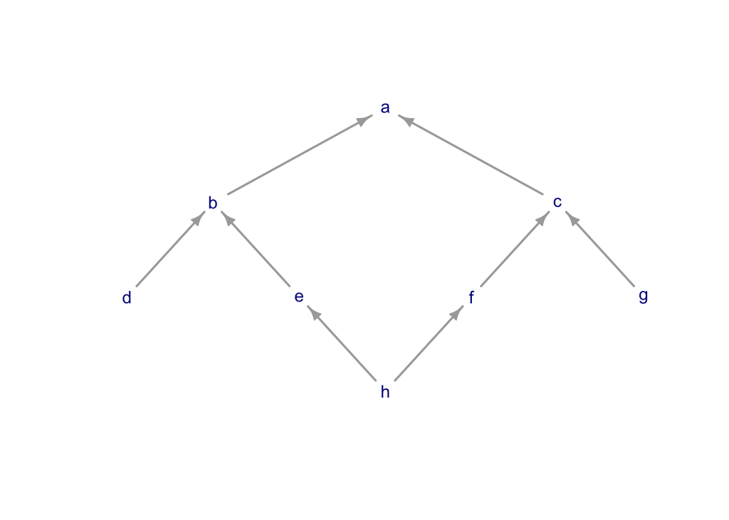

### Asymmetric

This case is similar but asymmetric. This case presents interesting complications for both algorithms.

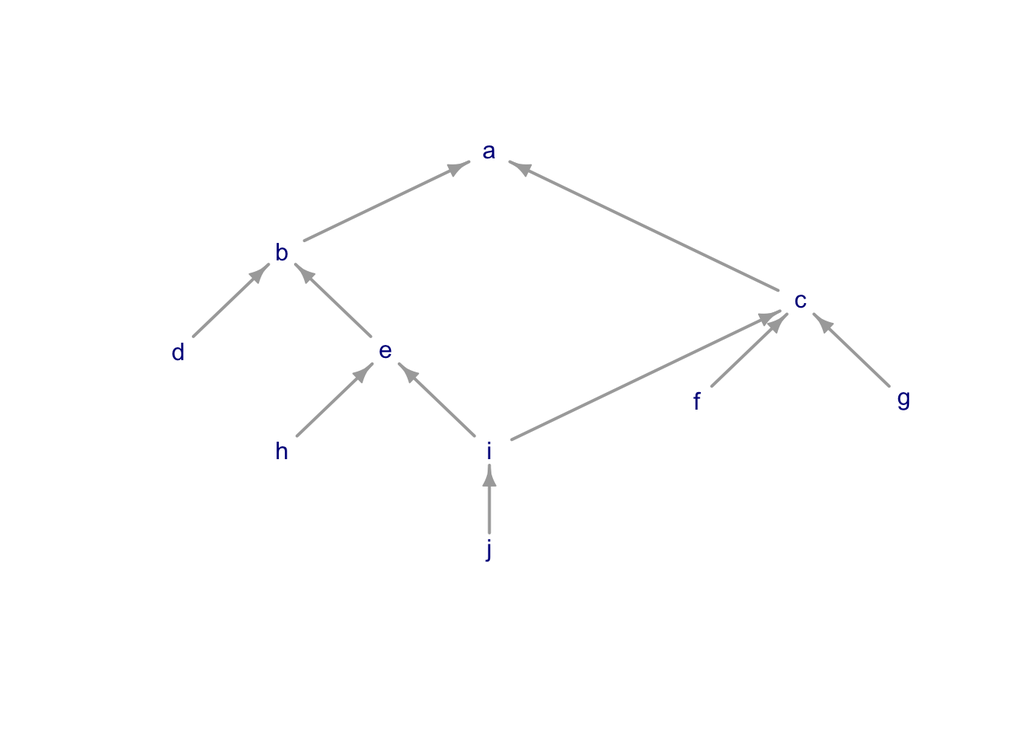

### Up-Down-Left-Right

This case is a somewhat contrived example that illustrates the cross of two orthogonal factors: up-down and left-right.

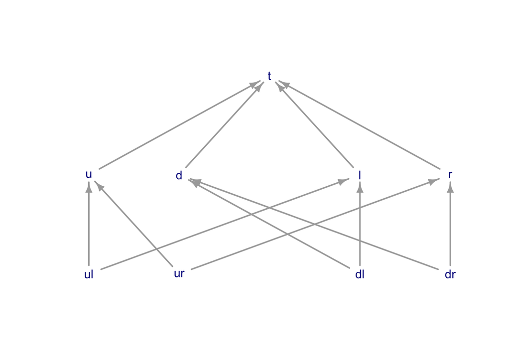

## Merge

The merge algorithm is based on the fact that, if *C* is a subclass of both *A* and *B*, then *C* is a subclass of *A* ∪ *B*. (Note: the converse is not true.) The merge algorithm merges the superclasses of any common subclass into their union. For this example, *A* and *B* cannot be disjoint because they no longer appear independently in the transformed tree.

### Simple Diamond

For this simple case, the merge algorithm is simple. *b* ⊆ *a* and *c* ⊆ *a* imply (*b* ∪ *c*) ⊆ *a*; *d* ⊆ *b* and *d* ⊆ *c* imply *d* ⊆ (*b* ∪ *c*). So the resulting transformed tree is:

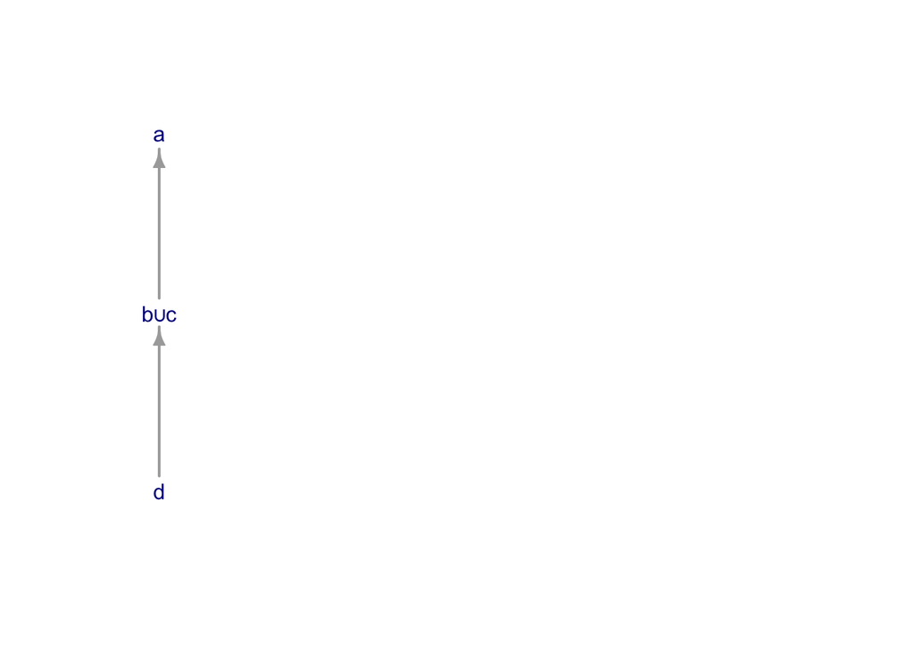

This tree contains no sibling subclasses. Hence, the set of disjointness axioms is empty.

### Symmetric 8

A deeper tree illustrates some subtleties of the merge algorithm. It is simple enough to observe, as before that *h* ⊆ (*e* ∪ *f*). But it is not necessarily the case that (*e* ∪ *f*) ⊆ *b* or (*e* ∪ *f*) ⊆ *c*. In order to preserve the consistency of the transformed taxonomy with the input, we merge *e* and *f* by first merging their most distant non-common ancestors, in this case *b* and *c*. If *e* and *f* share a common subclass (*h*), then every ancestor of *e* shares a common subclass with every ancestor of *f*. So no ancestor of *e* can be disjoint with any ancestor of *f*. In particular, *b* and *c* cannot be disjoint. Because *b* and *c* have all ancestors in common (namely *a*), we can replace *b* and *c* with *b* ∪ *c*.

Attempting to merge *e* and *f* results first in merging *b* and *c*:

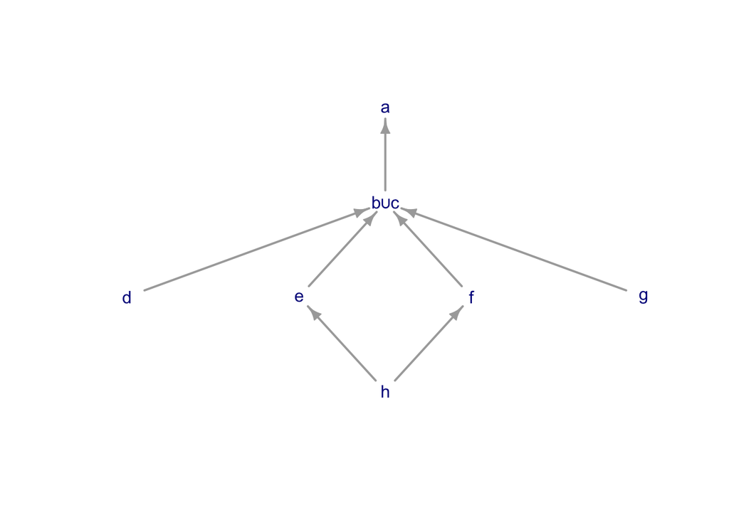

Now *e* and *f* have all ancestors in common and they can be merged:

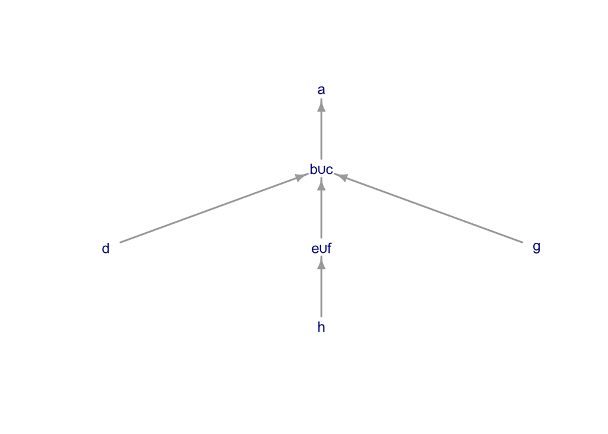

This taxonomy is a tree and implies the following disjointness:

```
DisjointClasses( d (e ∪ f) g )
```

### Asymmmetric

Applying the same logic results in merging *b* and *c*; the result is a tree:

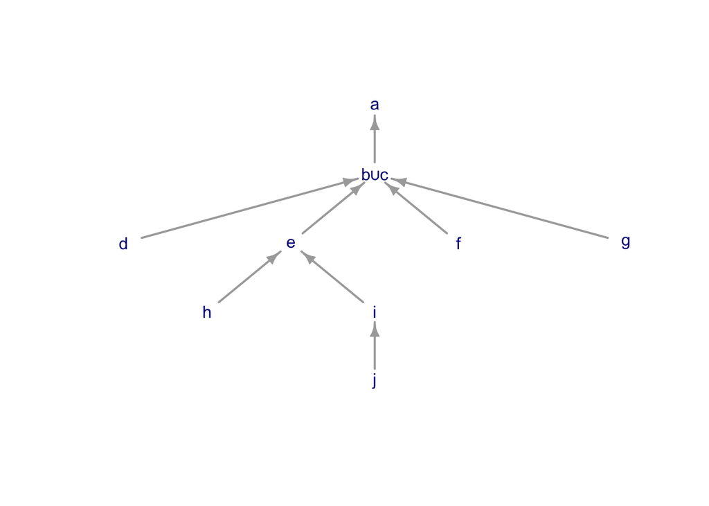

The implied disjointness is

```
DisjointClasses( d e f g )
DisjointClasses( h i )
```

### Up-Down-Left-Right

Repeated merging results in this tree:

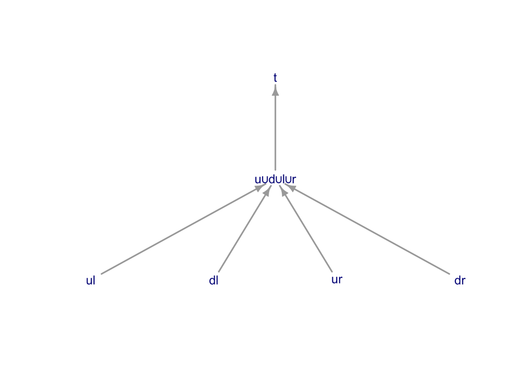

The implied disjointness is

```
DisjointClasses( ul ur dl dr )
```

## Bypass-Reduce-Isolate

The bypass-reduce-isolate algorithm exploits the fact that, for any two classes *A* and *B*, *A*\*B* is disjoint from *B*, where *A*\*B* is the *set difference*. It also makes use of the identity *A*\*B*\*C* = *A*\(*B* ∪ *C*).

### Simple Diamond

The simple diamond implies by transitivity that *d* ⊆ *a*. By the rule above, *b*\*d* and *c*\*d* are both disjoint with *d*. The result is a tree:

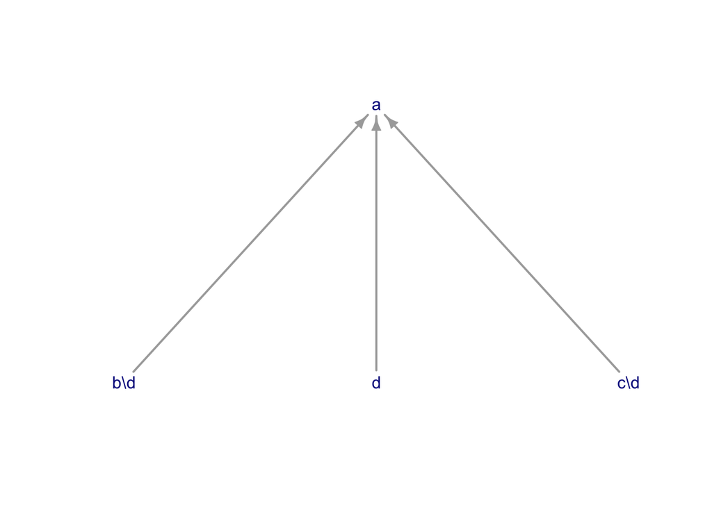

The implied disjointness is

```
DisjointClasses( b\d c\d d )
```

Note that the merge algorithm produces no disjointness axioms for this case.

### Symmetric 8

Repeated application of the rule produces this result for the deeper symmetric taxonomy:

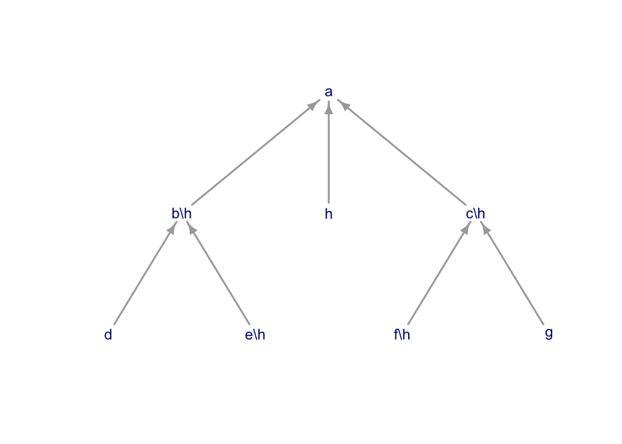

The implied disjointness is

```
DisjointClasses( b\h h c\h )
DisjointClasses( d e\h )
DisjointClasses( f\h g )
```

### Asymmetric

As its name implies, the bypass-reduce-isolate algorithm is implelemented with three fundamental operations.

For a subclass with multiple superclasses, the *bypass* operation moves the subclass “up” to the direct superclasses of its superclasses. In this case, the direct superclasses of *i* are *c* and *e*. After bypass, we have:

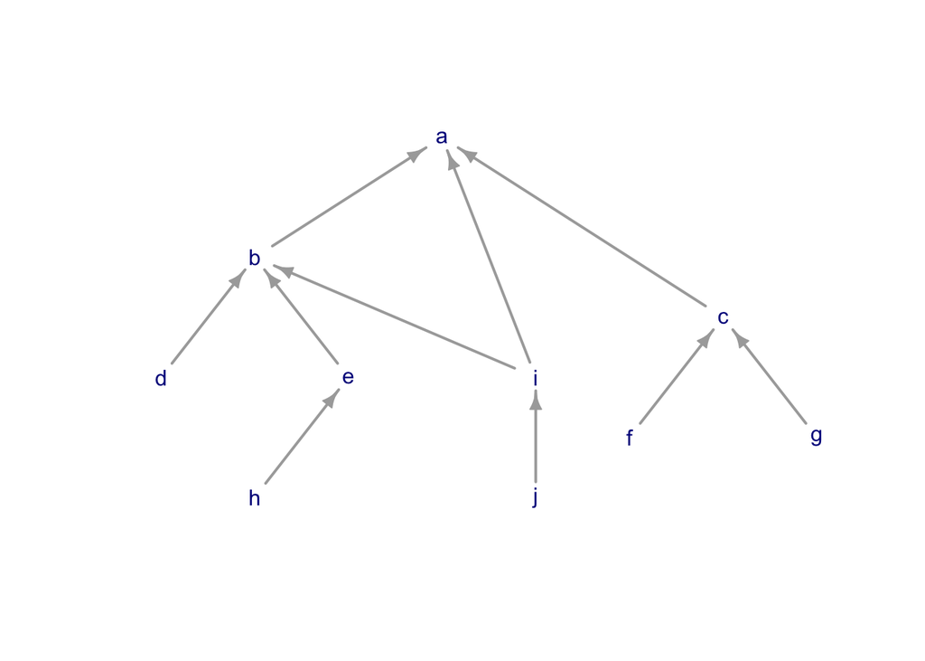

Note that this taxonomy is not in reduced form. The *reduce* operation removes reduntant edges introduced by the bypass:

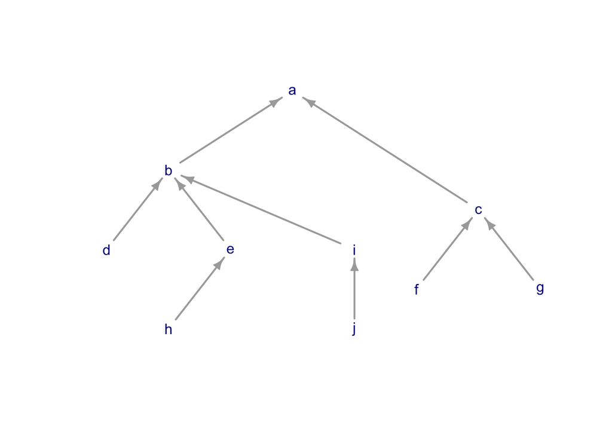

In principle, we could simply apply transitive reduction to the resulting taxonomy but that operation can be expensive on a large taxonomy. This implementation exploits the fact that all potentially reduntant edges are between the bypassing class and the root.

Note that the taxonomy in this state has lost essential information (e.g., that *c* and *e* share a common subclass *i*), and would therefore produce spurious disjointness. The *isolate* operation restores consistency with the original taxonomy by replacing *c* with *c*\*i* and *e* with *e*\*i*.

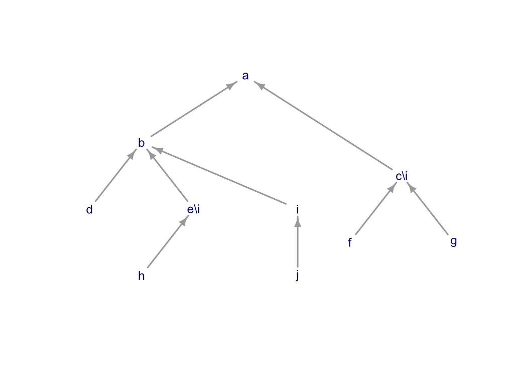

The implied disjointness is

```
DisjointClasses( b c\i )
DisjointClasses( d e\i i )
DisjointClasses( f g )
```

### Up-Down-Left-Right

Application of bypass-reduce-isolate in this case yields the following tree:

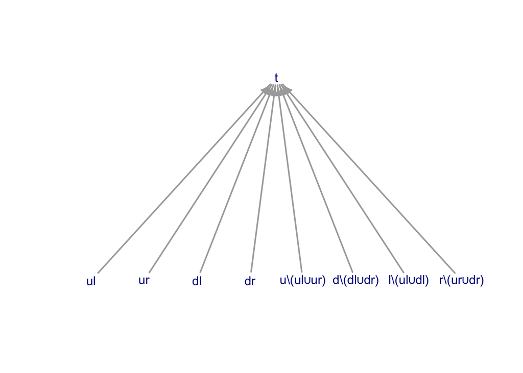

The implied disjointness is

```
DisjointClasses(ul ur dl dr u\(ul∪ur) d\(dl∪dr) l\(ul∪dl) r\(ur∪dr))
```

Note that if every element belongs to one of the leaf classes *ul*, *ur*, *dl*, or *dr*, then *u* = *ul* ∪ *ur*, and therefore *u*\(*ul* ∪ *ur*) is empty, and likewise for the other set differences. In this case the disjointness axioms are equivalent to those produced by the merge algorithm.

# The General Procedure

This section describes incorporation of either algorithm in a practical bundle closure application. For the purposes of this discussion, a bundle is a set of OML or OWL ontologies for which we want to assert disjointness in accordance with the policy state above.

1. Excise Pure Aspects. IMCE practice (enforced in OML) is to distinguish different usages of the notion of *class* in Description Logic. One usage in particular, known as *Aspects*, exist primarily to simplify the declarations of property domains and ranges and are not intended to represent a closed vocabulary. The first step in the process, therefore, is to excise all pure aspects. A pure aspect is any class that is a subclass of any aspect and is not also a subclass of any non-aspect. Excising a class means simply removing it from a taxonomy and making all its direct subclasses subclasses of its direct parents.
2. Excise Backbone Classes. In OWL, class usage distinctions are indicated by subclass relations to so-called *backbone classes*. Backbone classes are also not intended to represent a closed vocabulary, so we excise those as well.
3. Perform Transitive Reduction. As mentioned before, both algorithms assume the input taxonomy is in reduced form.
4. Treeify. While there exists a vertex with multiple parents, apply either *merge* or *bypass-reduce-isolate*. When no such vertex exists, the taxonomy is a tree.
5. Find Sibling Subclasses. Traverse the tree and, for each vertex, enumerate its sibling subclasses.
6. Assert Disjointness. For each set of sibling subclasses, asset a `DisjointClasses()` axiom. For the merge algorithm, the resulting disjointness axioms involve singleton classes and union expressions, which are created in OWL with `ObjectUnionOf()` expressions. For the bypass-reduce-isolate algorithm, the resulting expressions involve unions, and differences. OWL does not have an expression for set difference, but differences can be expressed using `ObjectIntersectionOf()` and `ObjectComplementOf()`.

# Prototype Implementation

The prototype implementation is a [JRuby](https://www.jruby.org/) [script](https://github.com/JPL-IMCE/gov.nasa.jpl.imce.ontologies.tools/blob/master/tools/close-tbox-bundle). Taxonomies are represented using the [Ruby Graph Library](https://www.rubydoc.info/github/monora/rgl), a pure Ruby package for graph operations. (JRuby is required for reading and writing OWL ontologies using the Java [OWLAPI](https://github.com/owlcs/owlapi).)

A key element of the implementation is a set of classes and methods for set expressions involving singletons, unions, intersections, and complements. The library does not perform general reasoning about sets, but exploits certain facts about set operations (e.g., set intersection is commutative and associative, set complement is involutory, etc.) to simplify the expressions.

The initial implementation is written in functional style: all graphs are immutable and iteration is achieved by recursion. For production use there is an iterative mode in which graphs are still immutable but references to them are mutable and iteration is achieved with conventional loops. The two modes pass identical unit tests.

There is a runtime option to select between merge and bypass-reduce-isolate algorithms. The latter produces stronger disjointness conditions and runs faster in general. In general, bypass-reduce-isolate produces more complex class expressions in its disjointness axioms; if this presents computational complexity difficulties for reasoners the merge algorithm may provide relief.